# Project_1_HF: Biomedical & Clinical Informatics

Merrimack College DSE6630: Healthcare & Life Sciences Analytics

Peter Gyorda

14 May 2026

# Introduction

Hospital readmissions are often used as an indicator of healthcare quality and patient outcomes. Identifying factors associated with higher readmission rates can help hospitals improve care and reduce unnecessary returns to the hospital.

For this project, data from the Centers for Medicare & Medicaid Services (CMS) available through Medicare.gov were used to examine hospital performance measures across the United States. The CMS datasets contain information about hospital quality, patient outcomes, and readmission rates. Because the data come from multiple sources and contain many variables, data cleaning, preprocessing, and exploratory analysis are necessary before meaningful conclusions can be drawn.

This analysis follows the same general workflow used in Demo 1 but focuses on heart failure (HF) readmissions rather than pneumonia-related readmissions.

Research Question

Which hospital characteristics are most strongly associated with heart failure readmission rates, and can hospitals be grouped into meaningful clusters based on these characteristics and outcomes?

## Question

For **Project 1**, the objective is to investigate factors associated with hospital readmission outcomes using publicly available CMS hospital quality data. For this analysis, the focus is on **heart failure (HF) readmissions**.

### Why heart failure readmissions?

Heart failure is one of the most common causes of hospitalization among older adults and remains a major contributor to healthcare utilization and costs in the United States. Patients discharged after treatment for heart failure often require ongoing monitoring and follow-up care, making readmission rates an important indicator of hospital performance and quality of care.

Because heart failure readmissions are tracked nationally by the Centers for Medicare & Medicaid Services (CMS), they provide a useful measure for evaluating differences in hospital outcomes and identifying characteristics associated with better or worse patient results.

#### Research Question

Which hospital characteristics are most strongly associated with heart failure readmission rates, and can hospitals be grouped into meaningful clusters based on quality measures, patient ratings, utilization metrics, and other performance indicators?

#### Hypothesis

Hospitals demonstrating stronger overall quality-of-care indicators, higher patient satisfaction ratings, and better clinical performance measures will tend to have lower heart failure readmission rates. Conversely, hospitals with lower performance on quality metrics may experience higher-than-average readmission rates due to differences in patient management, discharge planning, care coordination, and follow-up services.

## Objective

# Data & Data Cleaning

The CMS hospital quality datasets contain information on hospital performance, patient outcomes, utilization measures, and quality indicators collected from hospitals across the United States. Before analysis can begin, the data must be downloaded, combined, and prepared for use.

1. Download the **Hospitals** dataset as a zip archive. These files were originally obtained from the CMS Hospital Provider Data repository and include both 2024 and 2025 releases. For this project, only the **2024** data will be used.
2. Extract the contents of the zip archive to a local directory.
3. Update the file path below to match the location where the data were saved on your computer.

**Important:** Do not store these raw datasets in your GitHub repository because the files are too large to push successfully.

```r
## Make sure to adjust your path!
filepath <- "C:/hospital current data 2024/hospitals_10_2024/"
```

### Read in the hospital-level data iteratively, while dynamically naming & storing each file as a dataframe.

You may have to dig through the accompanying data dictionary **HOSPITAL_Data_Dictionary.pdf** to get a better handle on what is in the hospital-level files.

##### **Question 1**: [1 point]

Take a look at the chunk below, which performs **dynamic variable assignment** as it reads in each of the files. Your task is to add a comment to each line of code to describe what that line does.

> Your answer in the code chunk as comments. Make sure to use the `#` sign!

```r
# Create a list of all files in filepath whose names contain "Hospital.csv"
files <- list.files(path = filepath, pattern = "Hospital.csv")

# Loop through each file in the files list
for(f in 1:length(files)) {

    # Read the current CSV file into a temporary dataframe called dat
    dat <- read_csv(paste0(filepath, files[f]),

                    # Suppress display of detected column types
                    show_col_types = FALSE,

                    # Treat these values as missing values (NA)
                    na = c("", "NA", "N/A", "NULL", ".")
                    ) %>%

        # Standardize column names using UpperCamel case
        clean_names(case = "upper_camel") %>%

        # Automatically convert columns to appropriate data types
        type_convert() %>%

        # Convert any column containing "Date" into a date format
        mutate(across(contains("Date"), ~ mdy(.)))

    # Remove ".Hospital.csv" from the filename
    filename <- gsub(".Hospital\\.csv", "", files[f])

    # Create an R object using the filename and store the dataframe in it
    assign(filename, dat)
}

# Remove ".Hospital.csv" from all filenames and convert the result to a dataframe
files <- gsub(".Hospital\\.csv", "", files) %>% data.frame()

# Rename the dataframe column to "File Name"
names(files) <- "File Name"
```

#### Now, let’s look at a list of the files that we’ve read in:

Table 1. List of hospital-level data files.

| File Name |
| --- |
| Complications_and_Deaths |
| FY_2024_HAC_Reduction_Program |
| FY_2024_Hospital_Readmissions_Reduction_Program |
| HCAHPS |
| Health_Equity |
| Healthcare_Associated_Infections |
| Maternal_Health |
| Medicare_Hospital_Spending_Per_Patient |
| Outpatient_Imaging_Efficiency |
| Payment_and_Value_of_Care |
| Timely_and_Effective_Care |
| Unplanned_Hospital_Visits |

### Tidy the data response variables’ dataframe: Fiscal Year 2024 Hospital Readmissions Reduction Program.

We are going to focus on the dataset `FY_2024_Hospital_Readmissions_Reduction_Program` to work on best practices to [tidy our data](https://vita.had.co.nz/papers/tidy-data.pdf). Although I do not personally choose to follow everything that Hadley Wickham and the **Tidy Data** Movement has espoused, I do think a lot of the best practices are useful principles especially when we are just getting use to working with data. Further, we can leverage a lot of the functions to make our lives MUCH easier! And who doesn’t like easier?!

```r
sum(is.na(FY_2024_Hospital_Readmissions_Reduction_Program$NumberOfReadmissions))
```

```
## [1] 6697
```

```r
nrow(FY_2024_Hospital_Readmissions_Reduction_Program)
```

```
## [1] 18774
```

**Hint:** Columns 5 & 7:10 have problems with the `NA` class.

### Handling Suppressed Readmission Counts

Inspection of the NumberOfReadmissions variable revealed that some observations contain the text value “Too Few to Report” rather than a numeric count. According to the CMS data documentation, these values occur when the number of readmissions is sufficiently small that reporting the exact count could potentially compromise patient privacy. Because character values are mixed with numeric values, R imports the entire column as a character variable.

To preserve these observations while allowing the variable to be used in quantitative analyses, the suppressed values will be replaced with a placeholder value of 5 prior to converting the affected columns back to numeric format.

```r
FY_2024_Hospital_Readmissions_Reduction_Program <-
  FY_2024_Hospital_Readmissions_Reduction_Program %>%
  mutate(
    NumberOfReadmissions =
      gsub("Too Few to Report",
           "5",
           NumberOfReadmissions)
  )
```

You will notice that this aberrant class of missing value **caused** the numeric columns to be coerced into character columns when they were imported by `read_csv()`. Although we could try using `as.numeric()` by itself, which would assign `NA` to any non-numeric entry in `FY_2024_Hospital_Readmissions_Reduction_Program`, the problem is that we could lose important information that way. Thus, as annoying as this is, we should fix it a little more specifically…

##### **Question 5**: [1 point]

Look more closely at the `NumberOfReadmissions` column in the `FY_2024_Hospital_Readmissions_Reduction_Program`. What other issue do you see with this specific column that is coercing it to the character type, and why does it exist?

**Hint:** Make sure to use the accompanying data dictionary **HOSPITAL_Data_Dictionary.pdf** to also examine **WHY** this problem exists!

> The NumberOfReadmissions column contains the text value “Too Few to Report”, which causes the entire column to be stored as a character variable rather than numeric. This value is used by CMS when the number of cases is too small to report reliably. The suppression exists both to protect patient privacy and to avoid reporting potentially misleading statistics based on very small sample sizes. Because text is mixed with numeric values, R cannot automatically treat the column as numeric and coerces the entire variable to the character data type.

##### **Question 6**: [1 point]

Investigate the `gsub()` function that is part of base `R` or any other function of your choosing. Use the function you choose to **replace** the problematic text in the `NumberOfReadmissions` column in `FY_2024_Hospital_Readmissions_Reduction_Program` with a **5**.

```r
FY_2024_Hospital_Readmissions_Reduction_Program$NumberOfReadmissions <-
  gsub(
    "Too Few to Report",
    "5",
    FY_2024_Hospital_Readmissions_Reduction_Program$NumberOfReadmissions
  )
```

##### **Question 7**: [1 point]

Speculate as to why I asked you to replace the text with a **5** rather than a **0** or an `NA`. Can you think of any other logical choices for the substitution? Do you agree with my choice? (You’re free to disagree, but please defend your decision either way!)

> I believe the value 5 was chosen because the text “Too Few to Report” indicates that the number of readmissions was small but not necessarily zero. Replacing it with 0 would incorrectly assume that no readmissions occurred and would bias the results downward. Replacing it with NA would preserve the uncertainty, but it would also remove thousands of observations from later analyses and could reduce statistical power. Using 5 provides a reasonable midpoint estimate within the likely range of suppressed values and allows the observations to remain in the dataset. Other logical choices could include using the median of the reported readmission counts, the mean of the smallest reported values, or a randomly selected value from a plausible range. I generally agree with using 5 because it preserves the records while avoiding the unrealistic assumption that the number of readmissions was zero.

##### **Question 8**: [1 point]

Now, imagine an alternative scenario where instead of replacing it with a **5**, I instead asked you to replace it with a randomly sampled integer from 1 to 10. What would this do? Would `gsub()` work here or would I need to execute it a different way, e.g., with an `lapply()` function or a `for()` loop?

> Replacing “Too Few to Report” with a randomly sampled integer from 1 to 10 would introduce variability into the dataset and may provide a more realistic approximation than assigning the same value of 5 to every suppressed observation. However, each occurrence would need to receive its own randomly generated value. Because gsub() performs a simple text replacement and substitutes the same value everywhere, it would not be appropriate for assigning different random numbers to different rows. Instead, I would need to identify the rows containing “Too Few to Report” and then use a method such as a for() loop or lapply() to generate a different random value for each occurrence. This approach would preserve variation in the data rather than treating all suppressed observations as identical.

##### **Question 9**: [3 points]

You probably anticipated this! We just decided that, rather than a **5** we want a randomly sampled integer from 1 to 10.

**Hint 1:** You might find it easier to read the data in from fresh and, after commenting out your `gsub` from Question 5, pattern match on the problematic text.

**Hint 2:** This is NOT the only way to do this, but I solved this using `gregexpr()`, `regmatches()`, and `lapply()`.

```r
# Create a copy of the original column
tmp <- FY_2024_Hospital_Readmissions_Reduction_Program$NumberOfReadmissions

# Find all occurrences of the text
matches <- gregexpr("Too Few to Report", tmp)

# Replace each occurrence with a random integer from 1 to 10
regmatches(tmp, matches) <- lapply(
  regmatches(tmp, matches),
  function(x) as.character(sample(1:10, length(x), replace = TRUE))
)

# Save back to dataframe
FY_2024_Hospital_Readmissions_Reduction_Program$NumberOfReadmissions <- tmp

# Check results
table(FY_2024_Hospital_Readmissions_Reduction_Program$NumberOfReadmissions)
```

```
##
##  100  101  102  103  104  105  106  107  108  109   11  110  111  112  113  114
##   11   18   12   15   12    9   11    9   11   16  353   14    9    8   12   15
##  115  116  117  118  119   12  120  121  122  123  124  125  126  127  128  129
##    4   10    5    8    9  341   16   11    7    6    3   13   11   10    4    6
##   13  130  131  132  133  134  135  136  137  138  139   14  140  141  142  143
##  278   10    6   12    6    5    5    4    4    3    6  304    3    1    3    4
##  144  145  146  147  148  149   15  150  151  152  153  154  155  156  157  158
##    8    6    2    3    4    8  263    1    1    2    7    1    5    1    2    3
##  159   16  160  162  163  164  165  166  167  168  169   17  170  171  172  173
##    1  244    4    4    5    3    2    4    4    3    9  240    2    4    6    6
##  174  175  176  177  179   18  180  181  182  183  184  186  187  188  189   19
##    2    1    2    3    1  227    3    3    2    2    2    5    1    4    2  206
##  191  193  194  195  196  197  198  199   20  201  202  203  206  208  209   21
##    1    1    3    2    1    3    3    3  206    1    2    3    2    1    1  188
```

[output cut: 18 more lines]

##### **Question 10**: [1 point]

It is finally time to fix those aberrant character columns by making them numeric. However, just using `as.numeric()` would require us to do it over and over on each of the columns in multiple lines of code. Instead, investigate the function `mutate_at()` which will allow you to pass it a list of columns you want to convert with the function you want to use.

```r
FY_2024_Hospital_Readmissions_Reduction_Program <-
  FY_2024_Hospital_Readmissions_Reduction_Program %>%
  mutate_at(
    vars(
      NumberOfDischarges,
      ExcessReadmissionRatio,
      PredictedReadmissionRate,
      ExpectedReadmissionRate,
      NumberOfReadmissions
    ),
    as.numeric
  )
```

#### Let’s look more closely at Measure Names.

Notice, that what I have done here first is used the `gsub()` function to `mutate()` the `MeasureName` column to remove the text that flanked the medical conditions.

```r
FY_2024_Hospital_Readmissions_Reduction_Program <-  FY_2024_Hospital_Readmissions_Reduction_Program %>%
  mutate(MeasureName = gsub("READM-30-", "", MeasureName)) %>%
  mutate(MeasureName = gsub("-HRRP", "", MeasureName))
```

##### **Question 11**: [1 point]

Investigate the function `pivot_wider()` or `spread()` from the `tidyr` package, which comes bundled with `tidyverse`. Try pivoting the `FY_2024_Hospital_Readmissions_Reduction_Program` dataset wider. Make sure you correctly identify the `names_from` and `values_from` column(s). **Make sure to save it as a separate dataframe called `wideDF`.** Use the `dim()` function to prove to me that you successfully pivoted wider.

```r
wideDF <- FY_2024_Hospital_Readmissions_Reduction_Program %>%
  pivot_wider(
    names_from = MeasureName,
    values_from = NumberOfReadmissions
  )

dim(wideDF)
```

```
## [1] 16072    16
```

### Filtering for specific conditions.

Ideally, though, before we’d pivot wider we would decide if we were going to filter for any specific hospital readmission conditions. For your **Project 1**, you will be choosing which medical condition(s) you want to focus on for predicting hospital readmission. However, for the remainder of this demo, we’re going to focus on just **heart failure**.

**Ideas you might consider for your Project_1 are:**

- surgical interventions (`HIP-KNEE`, `CABG`)
- heart-related conditions (`HF`, `AMI`, & `CABG`)
- all conditions (warning: this might be too unwieldy!)
- any other condition(s) that you motivate with a statement or two in support

Therefore, let’s filter for just heart failure-related readmissions which will actually eliminate the need to pivot wider in just this case (because we only chose a single condition).

```r
readmissionsClean <-
  FY_2024_Hospital_Readmissions_Reduction_Program %>%
  filter(MeasureName == "HF")
```

Table 2. Acronyms of medical conditions for which hospital readmissions are tracked.

| Acronym | Definition |
| --- | --- |
| HIP-KNEE | Total Hip/Knee Arthroplasty |
| HF | Heart Failure |
| COPD | Chronic Obstructive Pulmonary Disease |
| AMI | Acute Myocardial Infarction |
| CABG | Coronary Artery Bypass Graft |
| PN | Pneumonia |

It’s important to understand that these medical conditions are the **ones that Medicaid/Medicare tracks for hospital readmissions**. These are not the only conditions in which a patient might be readmitted, but these are the ones that the agency uses to keep track of hospital performance.

### Dynamic creation of merged dataframe objects: supporting dataframes.

We will often be asked to deal with large, unwieldy datasets and sometimes we need to be able to handle them dynamically. **Dynamic variable assignment**, as I demonstrated when we read in the files, is going to come in handy - but it can sometimes be tricky to accomplish. The whole point, though, is to create code that can handle ANYTHING you throw at it.

In a similar vein, we can also perform **dynamic dataframe creation** when we need to modify and stitch together more than one pre-existing dataframe - ESPECIALLY when we might decide down the line to alter our choices by adding or removing other dataframes.

#### Writing your own function to create objects dynamically.

We are going to take all the cleaning steps we did above that was not specific to the `FY_2024_Hospital_Readmissions_Reduction_Program` dataframe and tidy, pivot, & filter for specific readmission conditions, and iteratively join as many dataframes as needed. The goal is to make something flexible enough that, if you change a set of inputs, it will create a joined table from ANY set of dataframe inputs. There is more than one way to do this; but leveraging some of the existing `tidyverse` and `tidyr` functions will likely help you make this very flexible. Please note, however, that you do not have to use those packages.

I start you out with something I find helpful when joining together dataframes that sometimes have *redundant* columns BUT not every column is in every dataframe. I start by making a dataframe called `hospitalInfo` that contains the pertinent information on each hospital in the dataset, so you can drop those columns from the other dataframes to prevent inflation or issues when you later join the dataframes together. You may want to join each of the other dataframes to `hospitalInfo`.

As I was writing my own version of this function, I found that the `Payment and Value of Care` table must be separated into two tables to join well, at least with how I wrote my function. So, I do that for you below. I also clean up `HCAHPS` to make it easier to work for the function I wrote, so it may also be useful for you. Note that what I’m doing in these cases is making sure that `MeasureName` is the title of the column **I will join my tables on.** In this way, I’m using the `MeasureName` as the **key** for my table joins.

**First, make sure to separate the Payment and Values tables, giving each facility IDs:**

```r
paymentOnly <- Payment_and_Value_of_Care %>%
  select(FacilityId, PaymentMeasureName, PaymentCategory, Payment) %>%
  mutate(Payment = gsub("\\$", "", Payment)) %>%
  mutate(Payment = gsub("\\,", "", Payment)) %>%
  mutate(Payment = as.numeric(Payment)) %>%   # convert payment to numeric
  rename(MeasureName = PaymentMeasureName)

valueOnly <- Payment_and_Value_of_Care %>%
  select(FacilityId, ValueOfCareDisplayName, ValueOfCareCategory) %>%
  rename(MeasureName = ValueOfCareDisplayName)
```

**HCAHPS is also a mess. Remove the columns that we will never use in any analysis, make a `MeasureName` column, and also drop the ” - linear mean score” from some rows in the newly minted `MeasureName`**

```r
HCAHPS <- HCAHPS %>%
  select(-HcahpsMeasureId, -PatientSurveyStarRatingFootnote,
         -HcahpsAnswerPercentFootnote, -NumberOfCompletedSurveysFootnote,
         -SurveyResponseRatePercentFootnote, -HcahpsAnswerDescription,
         -PatientSurveyStarRating) %>%  ## Drops the columns we don't need
  rename(MeasureName = HcahpsQuestion) %>%  ## Makes a new MeasureName column
  mutate(MeasureName = gsub(" - linear mean score", "", MeasureName))
  ## Takes off the phrase that we don't want
```

**Lastly, pull the hospital information off of the Payment and Value table because it is complete there. We can then drop this information from all the other tables:**

```r
hospitalInfo <- Payment_and_Value_of_Care %>%
              ## Information about the hospitals
                select(FacilityId, FacilityName, Address, CityTown,
                         State, ZipCode, CountyParish, TelephoneNumber)
```

##### **Question 12**: [5 points]

Write a function that will:

1. Fix any issues identified previously, e.g., issues with the `NA` class or pivoting, if needed
2. Join any number of a list of dataframes you give it. For example, it should be able to join these 8 tables:

```r
datList <- list(Healthcare_Associated_Infections,
                paymentOnly,
                Outpatient_Imaging_Efficiency,
                Complications_and_Deaths,
                Medicare_Hospital_Spending_Per_Patient,
                Timely_and_Effective_Care,
                Unplanned_Hospital_Visits,
                HCAHPS)
```

# Healthcare Associated Infections:

# Use the overall MRSA Bacteremia measure as a hospital infection quality indicator

```r
filterList <- list("MRSA Bacteremia",
                    "Payment for heart failure patients",
                   "Abdomen CT Use of Contrast Material",

                   c("Death rate for heart failure patients",
                    "Perioperative pulmonary embolism or deep vein thrombosis rate",
                     "CMS Medicare PSI 90: Patient safety and adverse events composite",
                      "Postoperative respiratory failure rate"),

                   "Medicare spending per patient",

                   c("Healthcare workers given influenza vaccination",
                     "Percentage of healthcare personnel who completed COVID-19 primary vaccination series",
                     "Average (median) time patients spent in the emergency department before leaving from the visit A lower number of minutes is better",
                     "Left before being seen",
                     "Venous Thromboembolism Prophylaxis",
                     "Intensive Care Unit Venous Thromboembolism Prophylaxis",
                     "Emergency department volume"),
                     "Hospital return days for heart failure patients",

                   c("Nurse communication",
                     "Doctor communication",
                     "Staff responsiveness",
                     "Communication about medicines",
                     "Discharge information",
                     "Care transition",
                     "Cleanliness",
                     "Quietness",
                     "Overall hospital rating",
                     "Recommend hospital")
)
```

```r
HF_Full <- tidyNjoin(
  datList = datList,
  filterList = filterList,
  hospitalInfo = hospitalInfo
)

dim(HF_Full)
```

[output not shown]

4. For full credit, make sure that your function can clean up and join together at least three of the dataframes. **Note**: Make sure to join with `readmissionsClean` at the end!

Perhaps you will choose to start your function like this (although you do not have to):

```r
tidyNjoin <- function(datList, filterList, hospitalInfo) {

}
```

- **Hint 1:** Feel free to drop the `startDate` and `endDate` columns, as well as the `footnote` column. I would even suggest dropping `MeasureId`.
- **Hint 2:** `select(-any_of(c(...)))` can be used to drop any of a list of columns, regardless of whether it exists in every dataframe or not.
- **Hint 3:** If you choose to drop all those extraneous columns, then the column you will need to merge/join on will always be in the second position, `MeasureName`.
- **Hint 4:** `full_join()` in `dplyr` is likely what you will need; you will want to execute the join on `FacilityId`.
- **Hint 5:** Make sure to check for and/or remove duplicate rows.
- **Hint 6:** Write *pseudocode*, which is using English to write out our programming logic. Then, use that pseudocode to have generative AI help you craft the function. Make sure to test it well! GenAI is often very wrong!
- **Hint 6:** If you are really stuck, move ahead and I give you a cleaned, merged data set to work with.

Okay, take a stab at it!

## Pivot/joining feature engineering

```r
tidyNjoin <- function(datList, filterList, hospitalInfo) {

  cleanList <- vector("list", length(datList))

  for(i in seq_along(datList)) {

    tempDF <- datList[[i]]

    # Remove unnecessary columns if present
    tempDF <- tempDF %>%
      select(
        -any_of(
          c(
            "StartDate",
            "EndDate",
            "Footnote",
            "MeasureId"
          )
        )
      )

    # Remove hospital information columns before joining
    tempDF <- tempDF %>%
      select(
        -any_of(
          c(
            "FacilityName",
            "Address",
            "CityTown",
            "State",
            "ZipCode",
            "CountyParish",
            "TelephoneNumber"
          )
        )
      )

    # Filter desired measures
    tempDF <- tempDF %>%
      filter(MeasureName %in% filterList[[i]])

    # Remove duplicate rows
    tempDF <- distinct(tempDF)

    ###################################################
    # HANDLE DATASETS WITH EXTRA COLUMNS
    ###################################################

    if(i == 4){

      tempDF <- tempDF %>%
        select(
          FacilityId,
          MeasureName,
          ComparedToNational
        )

      valueCol <- "ComparedToNational"

    } else if(i == 6){

      tempDF <- tempDF %>%
        select(
          FacilityId,
          MeasureName,
          Score
        )

      valueCol <- "Score"

    } else if(i == 8){

      tempDF <- tempDF %>%
        select(
          FacilityId,
          MeasureName,
          HcahpsAnswerPercent
        )

      valueCol <- "HcahpsAnswerPercent"

    } else {

      valueCol <- names(tempDF)[3]

    }

    ###################################################
    # PIVOT WIDER
    ###################################################

    tempDF <- tempDF %>%
      pivot_wider(
        names_from = MeasureName,
        values_from = all_of(valueCol)
      )

    cleanList[[i]] <- tempDF
  }

  # Join all cleaned tables together
  mergedDF <- Reduce(
    function(x, y) full_join(x, y, by = "FacilityId"),
    cleanList
  )

  # Join hospital information back in
  mergedDF <- full_join(
    hospitalInfo,
    mergedDF,
    by = "FacilityId"
  )

  # Join cleaned readmissions data
  mergedDF <- full_join(
    mergedDF,
    readmissionsClean,
    by = "FacilityId"
  )

  # Remove duplicate rows if any were created
  mergedDF <- distinct(mergedDF)

  return(mergedDF)
}
```

```r
HF_Model <- tidyNjoin(
  datList = datList,
  filterList = filterList,
  hospitalInfo = hospitalInfo
)

dim(HF_Model)
```

```
## [1] 4833   51
```

```r
head(HF_Model)
```

```
## # A tibble: 6 × 51
##   FacilityId FacilityName.x        Address CityTown State.x ZipCode CountyParish
##   <chr>      <chr>                 <chr>   <chr>    <chr>   <chr>   <chr>
## 1 010001     SOUTHEAST HEALTH MED… 1108 R… DOTHAN   AL      36301   HOUSTON
## 2 010005     MARSHALL MEDICAL CEN… 2505 U… BOAZ     AL      35957   MARSHALL
## 3 010006     NORTH ALABAMA MEDICA… 1701 V… FLORENCE AL      35630   LAUDERDALE
## 4 010007     MIZELL MEMORIAL HOSP… 702 N … OPP      AL      36467   COVINGTON
## 5 010008     CRENSHAW COMMUNITY H… 101 HO… LUVERNE  AL      36049   CRENSHAW
## 6 010011     ST. VINCENT'S EAST    50 MED… BIRMING… AL      35235   JEFFERSON
## # ℹ 44 more variables: TelephoneNumber <chr>, Score.x <chr>,
## #   `MRSA Bacteremia` <chr>, Payment <dbl>,
## #   `Payment for heart failure patients` <chr>,
## #   `Abdomen CT Use of Contrast Material` <chr>,
## #   `Death rate for heart failure patients` <chr>,
## #   `Postoperative respiratory failure rate` <chr>,
## #   `Perioperative pulmonary embolism or deep vein thrombosis rate` <chr>, …
```

###### Categorical Feature Encoding

```r
HF_Model <- HF_Model %>%
  mutate(

    `MRSA Bacteremia` =
      case_when(
        `MRSA Bacteremia` == "Better than the National Benchmark" ~ 2,
        `MRSA Bacteremia` == "No Different than National Benchmark" ~ 1,
        `MRSA Bacteremia` == "Worse than the National Benchmark" ~ 0,
        TRUE ~ NA_real_
      ),

    `Death rate for heart failure patients` =
      case_when(
        `Death rate for heart failure patients` ==
          "Better Than the National Rate" ~ 2,

        `Death rate for heart failure patients` ==
          "No Different Than the National Rate" ~ 1,

        `Death rate for heart failure patients` ==
          "Worse Than the National Rate" ~ 0,

        TRUE ~ NA_real_
      ),

    `Hospital return days for heart failure patients` =
      case_when(
        `Hospital return days for heart failure patients` ==
          "Fewer Days Than Average per 100 Discharges" ~ 2,

        `Hospital return days for heart failure patients` ==
          "Average Days per 100 Discharges" ~ 1,

        `Hospital return days for heart failure patients` ==
          "More Days Than Average per 100 Discharges" ~ 0,

        TRUE ~ NA_real_
      )
  )
```

###### Remove Administrative columns

```r
HF_Model <- HF_Model %>%
  select(
    -FacilityName.x,
    -FacilityName.y,
    -Address,
    -CityTown,
    -State.x,
    -State.y,
    -ZipCode,
    -CountyParish,
    -TelephoneNumber,
    -MeasureName,
    -StartDate,
    -EndDate,
    -Footnote
  )
```

```r
table(
  HF_Model$`Hospital return days for heart failure patients`,
  useNA = "ifany"
)
```

```
##
##    0    1    2 <NA>
##  485 2418  296 1634
```

##### Encode performance categories

```r
HF_Model <- HF_Model %>%
  mutate(

    `MRSA Bacteremia` =
      case_when(
        `MRSA Bacteremia` == "Better than the National Benchmark" ~ 2,
        `MRSA Bacteremia` == "No Different than National Benchmark" ~ 1,
        `MRSA Bacteremia` == "Worse than the National Benchmark" ~ 0,
        TRUE ~ NA_real_
      ),

    `Death rate for heart failure patients` =
      case_when(
        `Death rate for heart failure patients` ==
          "Better Than the National Rate" ~ 2,

        `Death rate for heart failure patients` ==
          "No Different Than the National Rate" ~ 1,

        `Death rate for heart failure patients` ==
          "Worse Than the National Rate" ~ 0,

        TRUE ~ NA_real_
      )
  )
```

##### Convert numeric columns

```r
HF_Model <- HF_Model %>%
  mutate(
    across(
      c(
        Score.x,
        Score.y,
        Denominator,
        LowerEstimate,
        HigherEstimate,
        NumberOfPatients,
        NumberOfPatientsReturned,
        NumberOfDischarges,
        ExcessReadmissionRatio,
        PredictedReadmissionRate,
        ExpectedReadmissionRate,
        NumberOfReadmissions
      ),
      as.numeric
    )
  )
```

##### Verify

```r
     summary(
  HF_Model %>%
    select(
      `MRSA Bacteremia`,
      `Death rate for heart failure patients`,
      `Hospital return days for heart failure patients`
    )
)
```

```
##  MRSA Bacteremia Death rate for heart failure patients
##  Min.   : NA     Min.   : NA
##  1st Qu.: NA     1st Qu.: NA
##  Median : NA     Median : NA
##  Mean   :NaN     Mean   :NaN
##  3rd Qu.: NA     3rd Qu.: NA
##  Max.   : NA     Max.   : NA
##  NA's   :4833    NA's   :4833
##  Hospital return days for heart failure patients
##  Min.   :0.0000
##  1st Qu.:1.0000
##  Median :1.0000
##  Mean   :0.9409
##  3rd Qu.:1.0000
##  Max.   :2.0000
##  NA's   :1634
```

#### Create observed admission rate

```r
HF_Model <- HF_Model %>%
  mutate(
    observed_readmission_rate =
      NumberOfReadmissions / NumberOfDischarges
  )
```

##### Check the new target variable

```r
summary(HF_Model$observed_readmission_rate)
```

```
##    Min. 1st Qu.  Median    Mean 3rd Qu.    Max.    NA's
##  0.0727  0.1779  0.2021  0.2046  0.2279  0.4000    2528
```

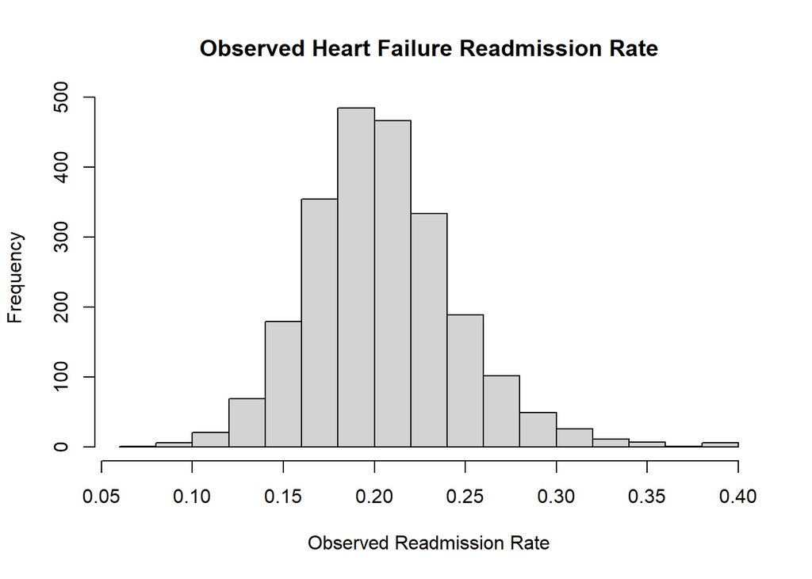

```r
hist(
  HF_Model$observed_readmission_rate,
  main = "Observed Heart Failure Readmission Rate",
  xlab = "Observed Readmission Rate"
)
```

##### Look at missing values

```r
colSums(is.na(HF_Model)) |>
  sort(decreasing = TRUE)
```

```
##                                                                                                                    MRSA Bacteremia
##                                                                                                                               4833
##                                                                                              Death rate for heart failure patients
##                                                                                                                               4833
##                                                                                                                            Score.x
##                                                                                                                               3122
##                                                                                                          observed_readmission_rate
##                                                                                                                               2528
##                                                                                                                 NumberOfDischarges
##                                                                                                                               2515
##                                                                                                             ExcessReadmissionRatio
##                                                                                                                               2198
##                                                                                                           PredictedReadmissionRate
##                                                                                                                               2198
##                                                                                                            ExpectedReadmissionRate
##                                                                                                                               2198
##                                                                                                               NumberOfReadmissions
##                                                                                                                               2198
##                                                                                                                            Payment
##                                                                                                                               1856
##                                                                                                                        Denominator
##                                                                                                                               1634
##                                                                                                                            Score.y
##                                                                                                                               1634
##                                                                                                                      LowerEstimate
##                                                                                                                               1634
##                                                                                                                     HigherEstimate
##                                                                                                                               1634
##                                                                                                                   NumberOfPatients
##                                                                                                                               1634
##                                                                                                           NumberOfPatientsReturned
##                                                                                                                               1634
##                                                                                    Hospital return days for heart failure patients
##                                                                                                                               1634
##                                                                                                 Venous Thromboembolism Prophylaxis
##                                                                                                                                372
##                                                                             Intensive Care Unit Venous Thromboembolism Prophylaxis
##                                                                                                                                372
##                                                                                                 Payment for heart failure patients
##                                                                                                                                218
```

[output cut: 23 more lines]

```
##                                                                                                                                 54
##                                                                                                              Discharge information
##                                                                                                                                 54
##                                                                                                                    Care transition
##                                                                                                                                 54
##                                                                                                                        Cleanliness
##                                                                                                                                 54
##                                                                                                                          Quietness
##                                                                                                                                 54
##                                                                                                            Overall hospital rating
##                                                                                                                                 54
##                                                                                                                 Recommend hospital
##                                                                                                                                 54
##                                                                                                                         FacilityId
##                                                                                                                                  0
```

#### Create final modeling data set

```r
HF_Ready <- HF_Model %>%
  filter(!is.na(observed_readmission_rate))
```

##### Validate the data set

```r
# Check dimensions
dim(HF_Ready)
```

```
## [1] 2305   39
```

```r
# Check for duplicate hospitals
sum(duplicated(HF_Ready$FacilityId))
```

```
## [1] 0
```

```r
# Check target variable
summary(HF_Ready$observed_readmission_rate)
```

```
##    Min. 1st Qu.  Median    Mean 3rd Qu.    Max.
## 0.07273 0.17788 0.20213 0.20463 0.22792 0.40000
```

```r
# Missing values by variable
colSums(is.na(HF_Ready)) |>
  sort(decreasing = TRUE)
```

```
##                                                                                                                    MRSA Bacteremia
##                                                                                                                               2305
##                                                                                              Death rate for heart failure patients
##                                                                                                                               2305
##                                                                                                                            Score.x
##                                                                                                                                669
##                                                                                                                            Payment
##                                                                                                                                 19
##                                                                                                                        Denominator
##                                                                                                                                 18
##                                                                                                                            Score.y
##                                                                                                                                 18
##                                                                                                                      LowerEstimate
##                                                                                                                                 18
##                                                                                                                     HigherEstimate
##                                                                                                                                 18
##                                                                                                                   NumberOfPatients
##                                                                                                                                 18
##                                                                                                           NumberOfPatientsReturned
##                                                                                                                                 18
##                                                                                    Hospital return days for heart failure patients
##                                                                                                                                 18
##                                                                                                 Venous Thromboembolism Prophylaxis
##                                                                                                                                 16
##                                                                             Intensive Care Unit Venous Thromboembolism Prophylaxis
##                                                                                                                                 16
##                                                                                                 Payment for heart failure patients
##                                                                                                                                 15
##                                                                                                Abdomen CT Use of Contrast Material
##                                                                                                                                 15
##                                                                                             Postoperative respiratory failure rate
##                                                                                                                                 15
##                                                                      Perioperative pulmonary embolism or deep vein thrombosis rate
##                                                                                                                                 15
##                                                                   CMS Medicare PSI 90: Patient safety and adverse events composite
##                                                                                                                                 15
##                                                                                                        Emergency department volume
##                                                                                                                                 15
##                                                                                     Healthcare workers given influenza vaccination
##                                                                                                                                 15
```

[output cut: 23 more lines]

```
##                                                                                                                                 15
##                                                                                                                         FacilityId
##                                                                                                                                  0
##                                                                                                                 NumberOfDischarges
##                                                                                                                                  0
##                                                                                                             ExcessReadmissionRatio
##                                                                                                                                  0
##                                                                                                           PredictedReadmissionRate
##                                                                                                                                  0
##                                                                                                            ExpectedReadmissionRate
##                                                                                                                                  0
##                                                                                                               NumberOfReadmissions
##                                                                                                                                  0
##                                                                                                          observed_readmission_rate
##                                                                                                                                  0
```

[figure not shown]

[output not shown]

```r
# Visualize target distribution
hist(
  HF_Ready$observed_readmission_rate,
  main = "Observed Heart Failure Readmission Rate",
  xlab = "Observed Readmission Rate"
)
```

## Create Heart Failure Dataset

```r
HF_Readmissions <-
  FY_2024_Hospital_Readmissions_Reduction_Program %>%
  filter(MeasureName == "HF")

dim(HF_Readmissions)
```

```
## [1] 3129   12
```

```r
head(HF_Readmissions)
```

```
## # A tibble: 6 × 12
##   FacilityName          FacilityId State MeasureName NumberOfDischarges Footnote
##   <chr>                 <chr>      <chr> <chr>                    <dbl>    <dbl>
## 1 SOUTHEAST HEALTH MED… 010001     AL    HF                         616       NA
## 2 MARSHALL MEDICAL CEN… 010005     AL    HF                         129       NA
## 3 NORTH ALABAMA MEDICA… 010006     AL    HF                         441       NA
## 4 MIZELL MEMORIAL HOSP… 010007     AL    HF                          NA       NA
## 5 CRENSHAW COMMUNITY H… 010008     AL    HF                          NA        1
## 6 ST. VINCENT'S EAST    010011     AL    HF                         251       NA
## # ℹ 6 more variables: ExcessReadmissionRatio <dbl>,
## #   PredictedReadmissionRate <dbl>, ExpectedReadmissionRate <dbl>,
## #   NumberOfReadmissions <dbl>, StartDate <date>, EndDate <date>
```

##### Create paymentOnly dataset

```r
paymentOnly <- Payment_and_Value_of_Care %>%
  select(
    FacilityId,
    PaymentMeasureName,
    Payment
  ) %>%
  rename(
    MeasureName = PaymentMeasureName
  )
```

```r
# HF_Ready created successfully
dim(HF_Ready)
```

```
## [1] 2305   39
```

Box, G. E. P., and D. R. Cox. 2018. “An Analysis of Transformations.” *Journal of the Royal Statistical Society: Series B (Methodological)* 26 (2): 211–43. https://doi.org/10.1111/j.2517-6161.1964.tb00553.x.

De Alba, Israel, and Alpesh Amin. 2014. “Pneumonia Readmissions: Risk Factors and Implications.” *Ochsner Journal* 14 (4): 649–54.

R Core Team. 2019. *R: A Language and Environment for Statistical Computing*. Vienna, Austria: R Foundation for Statistical Computing. https://www.R-project.org.

Yeo, In‐Kwon, and Richard A. Johnson. 2000. “A New Family of Power Transformations to Improve Normality or Symmetry.” *Biometrika* 87 (4): 954–59. https://doi.org/10.1093/biomet/87.4.954.

Zou, Hui, and Trevor Hastie. 2005. “Regularization and Variable Selection via the Elastic Net.” *Journal of the Royal Statistical Society Series B: Statistical Methodology* 67 (2): 301–20. https://doi.org/10.1111/j.1467-9868.2005.00503.x.